# **Lab 3: Optical satellite imagery**

Hans Ole Ørka, 4. September 2026

# **Part 1: Modelling and prediction of forest attributes**

**Goal:** Combine reference data collected in a forested area with Sentinel-2 satellite imagery to map dominant species and above-ground biomass (AGB). In this process, unsupervised and supervised approaches to analyzing categorical and continuous attributes in optical satellite imagery are explored.

**Data:** The data for the lab can be be downloaded from the link below. The data include a GeoPackage with field reference data of dominant species (Spruce, Pine, Broadleaves) and AGB (Mg/ha) and an area of interest polygon (AOI).

- https://eduumb.sharepoint.com/:f:/s/team_mina305instructors/IgDQvt_W2pV1R5HfIFdT2CGeAdrRPM7_O-uKhNYUjWTDVUs?e=mWPNFP

**Note:** Download the folders separately. Before decompressing (Extract all) the folder “S2B_MSIL2A_20220624T104629_R051_T32VNM_20220624T122953.SAFE”, rename it “S2” to avoid error caused by long path name on Windows.

**Overview**: The figure below illustrates the steps in the lab exercise and how they relate to classification and regression methods, as well as to supervised and unsupervised approaches.

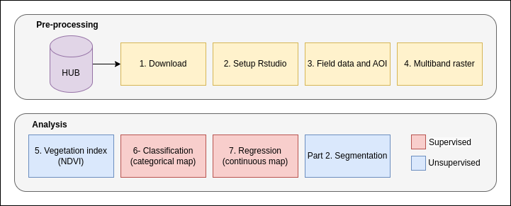

## 1. Download Sentinel-2 data

- Download Sentinel-2 data from https://browser.dataspace.copernicus.eu/ or use the data provided in the sharepoint. The field inventory was carried out in summer 2022.

In the lab report, include the *.SAFE name on the folder. In this case: *S2B_MSIL2A_20220624T104629_N0400_R051_T32VNM_20220624T122953.SAFE*

## 2. Rstudio

Instructions for setting up a project in RStudio:

1. Open RStudio.
2. Create a new project.
3. Within the project directory, establish two folders: *data* (for storing data) and *R* (for housing scripts).
4. Store the geopackage and sentinel-2 files inside the *data* folder.
5. This approach ensures data file paths are relative to the *.Rproj file, improving code readability. Please be aware that when using OneDrive, it’s advisable to use the entire file path and remember to employ forward slashes (“/”) instead of backslashes (“\”) to avoid potential issues.

## 3. Read and explore field reference data (vector data)

The field reference data is stored with the GPS location coordinates (point) and can be read using the *sf* package. When using it in conjunction with the *terra* package for raster or image data, ensure that you convert it using the *vect* function.

```r
# Read field reference data and AOI
library(sf)
gpkg <- "data/lab3.gpkg" # Path of geopackage
st_layers(gpkg) # List layers in geopackage
```

```
Driver: GPKG
Available layers:
```

| layer_name | geometry_type | features | fields | crs_name |
| --- | --- | --- | --- | --- |
| SamplePlots | Point | 136 | 5 | WGS 84 / UTM zone 32N |
| AOI | Polygon | 1 | 0 | WGS 84 / UTM zone 32N |

```r
prfl <- st_read(gpkg,"SamplePlots") # Read sample plots
head(prfl) # Print the top of the data
```

```
Simple feature collection with 6 features and 5 fields
Geometry type: POINT
Dimension:     XY
Bounding box:  xmin: 606588.2 ymin: 6597407 xmax: 607357 ymax: 6599713
Projected CRS: WGS 84 / UTM zone 32N
  plotID SiteIndex Age       AGB Species                     geom
1    P10        14   9 272.74768  Spruce POINT (607027.4 6599713)
2   P100        14  40 191.61090    Pine   POINT (607357 6598226)
3   P101        11  55  91.35791  Spruce POINT (606905.5 6597814)
4   P102        11  55 149.58604    Pine   POINT (606806 6597709)
5   P104        14  40 253.98047  Spruce POINT (606588.2 6597529)
6   P105        11  65 139.92369  Spruce POINT (606675.4 6597407)
```

```r
summary(prfl) # Print a summary of the data
```

```
       plotID      SiteIndex          Age              AGB             Species               geom
 Length   :136   Min.   : 8.00   Min.   :  9.00   Min.   : 11.3   Length   :136   POINT        :136
 N.unique :136   1st Qu.:11.00   1st Qu.: 30.00   1st Qu.:110.4   N.unique :  3   epsg:32632   :  0
 N.blank  :  0   Median :14.00   Median : 45.00   Median :147.0   N.blank  :  0   +proj=utm ...:  0
 Min.nchar:  2   Mean   :13.47   Mean   : 57.54   Mean   :159.3   Min.nchar:  4
 Max.nchar:  4   3rd Qu.:14.75   3rd Qu.: 90.00   3rd Qu.:196.8   Max.nchar: 11
                 Max.   :20.00   Max.   :130.00   Max.   :568.4
```

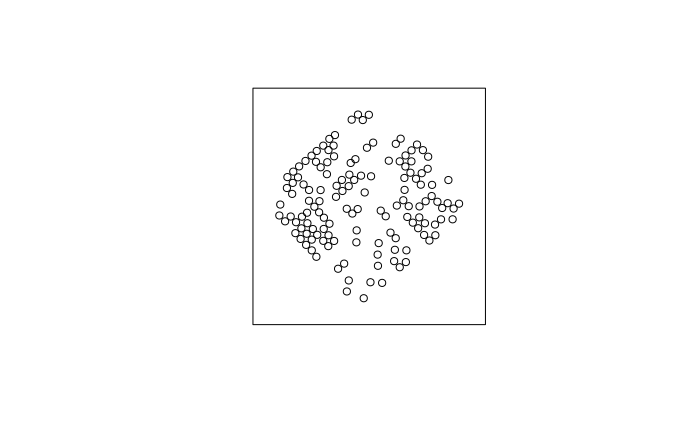

```r
aoi <- st_read(gpkg,"AOI") # Read area of interest polygon
plot(st_geometry(aoi))
plot(st_geometry(prfl),add=T) #plot the geometry stored in the attribute geom
```

## 4. Create multiband raster

The Sentinel-2 bands are stored separately. Create multiband images at 10 and 20 m resolution covering the aoi and write to disk. Functions for listing files (*dir*), *rast* and *crop* functions needed. If there are problems with downloading data (approximately 1 GB), the results from this step can be downloaded from: https://eduumb.sharepoint.com/:f:/s/team_mina305instructors/IgDQvt_W2pV1R5HfIFdT2CGeAdrRPM7_O-uKhNYUjWTDVUs?e=mWPNFP

```r
library(terra)
# List files in a specific path
path <- "data/S2B_MSIL2A_20220624T104629_N0400_R051_T32VNM_20220624T122953.SAFE/GRANULE/L2A_T32VNM_A027676_20220624T104625/IMG_DATA/R10m/"
f1 <- dir(path,pattern="_B",full.names=T) # list all files containing _B
f1
```

```
[1] "data/S2B_MSIL2A_20220624T104629_N0400_R051_T32VNM_20220624T122953.SAFE/GRANULE/L2A_T32VNM_A027676_20220624T104625/IMG_DATA/R10m//T32VNM_20220624T104629_B02_10m.jp2"
[2] "data/S2B_MSIL2A_20220624T104629_N0400_R051_T32VNM_20220624T122953.SAFE/GRANULE/L2A_T32VNM_A027676_20220624T104625/IMG_DATA/R10m//T32VNM_20220624T104629_B03_10m.jp2"
[3] "data/S2B_MSIL2A_20220624T104629_N0400_R051_T32VNM_20220624T122953.SAFE/GRANULE/L2A_T32VNM_A027676_20220624T104625/IMG_DATA/R10m//T32VNM_20220624T104629_B04_10m.jp2"
[4] "data/S2B_MSIL2A_20220624T104629_N0400_R051_T32VNM_20220624T122953.SAFE/GRANULE/L2A_T32VNM_A027676_20220624T104625/IMG_DATA/R10m//T32VNM_20220624T104629_B08_10m.jp2"
```

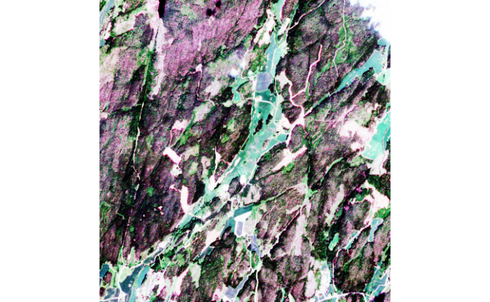

```r
# Read all files
s <- rast(f1)
s2_10m <- crop(s,aoi) # Clip raster to aoi
names(s2_10m) <- c("Blue","Green","Red","NIR") # Rename bands
names(s2_10m) <- paste0(names(s2_10m),"_10m") # Concatenate resolution's name to band, to make it unique
plotRGB(s2_10m,r=3,g=2,b=1,stretch="hist")
```

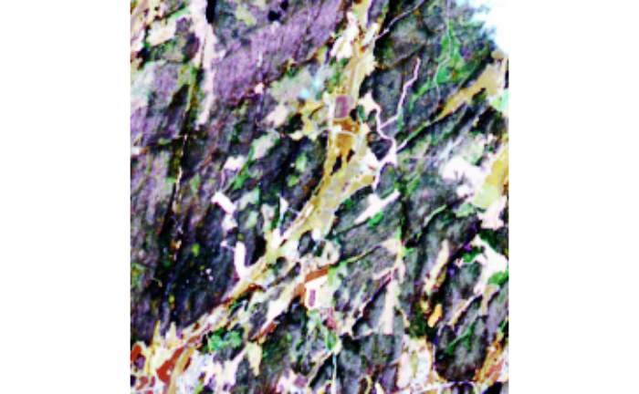

```r
#writeRaster(s2_10m,"data/sentinel2_10m.tif") # Optionally write file to have access to it in GIS software

# Do the same for 20 m resolution bands
path <- "data/S2B_MSIL2A_20220624T104629_N0400_R051_T32VNM_20220624T122953.SAFE/GRANULE/L2A_T32VNM_A027676_20220624T104625/IMG_DATA/R20m/"
f1 <- dir(path,pattern="_B",full.names=T)
s <- rast(f1)
s2_20m <- crop(s,vect(aoi))
names(s2_20m) <- c("CostalAerosol","Blue","Green","Red","RE1","RE2","RE3","SWIR1","SWIR2","RE4")
names(s2_20m) <- paste0(names(s2_20m),"_20m")
plotRGB(s2_20m,r=8,g=5,b=4,stretch="hist")
```

```r
#writeRaster(s2_20m,"data/sentinel2_20m.tif")
```

### 5. Create vegetation index

The task involves creating an NDVI raster and then exploring NDVI differences based on species, above-ground biomass (AGB), and age by assigning NDVI values to sample plots and visualizing the relationships.

1. Calculate the NDVI from your multispectral imagery (e.g., Sentinel-2) using the formula: NDVI = (NIR - Red) / (NIR + Red), where NIR is near-infrared and Red is the red band.
2. Use the *extract* function to assign NDVI values to sample plots.
3. Explore the relationships through scatter plots of species, age, and AGB on the x-axis and NDVI on the y-axis (or employ other methods to investigate these relationships). The *ggplot2* package provides extensive and excellent plotting capabilities.

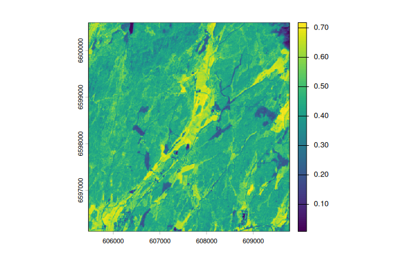

```r
library(ggplot2)
# Compute NDVI and plot by Species, AGB, Age. Any strange observations? This can potentially be used for checking errors (e.g. harvest!)
ndvi <- (s2_10m$NIR_10m - s2_10m$Red_10m)/(s2_10m$NIR_10m + s2_10m$Red_10m) # Compute NDVI
plot(ndvi)
```

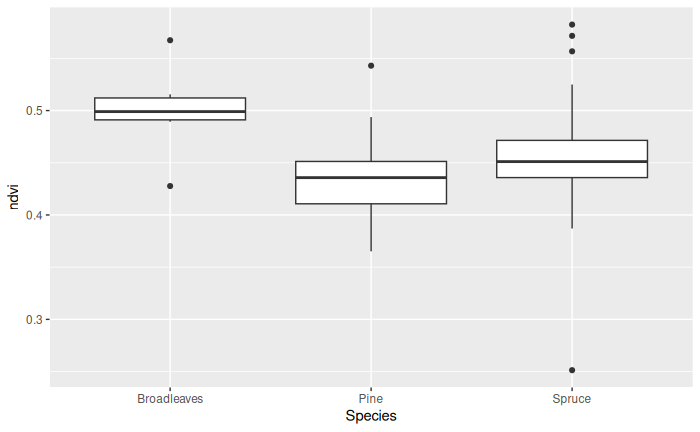

```r
e2 <- extract(ndvi,prfl) # Extract NDVI at sample plot locations
prfl$ndvi <- e2[,2] # Assign extracted NDVI values to prfl (Point geometries gives a one-to-one relationship)
ggplot(prfl,aes(x=Species,y=ndvi)) + geom_boxplot() # Box plot of NDVI by species
```

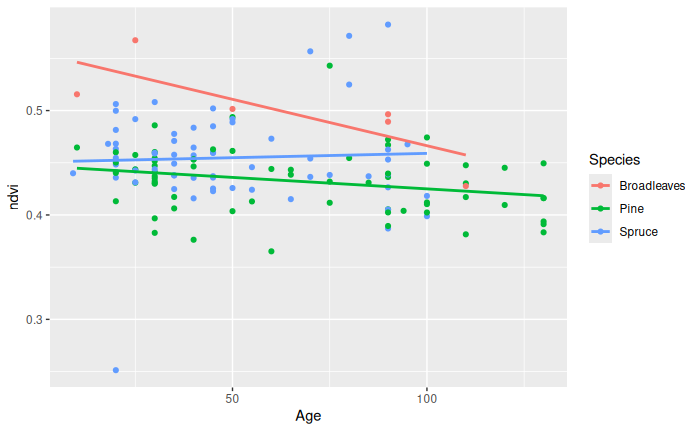

```r
ggplot(prfl,aes(x=Age,y=ndvi,color=Species)) + geom_point() + geom_smooth(method="lm",se=FALSE) # Scatterplot with linear regression lines
```

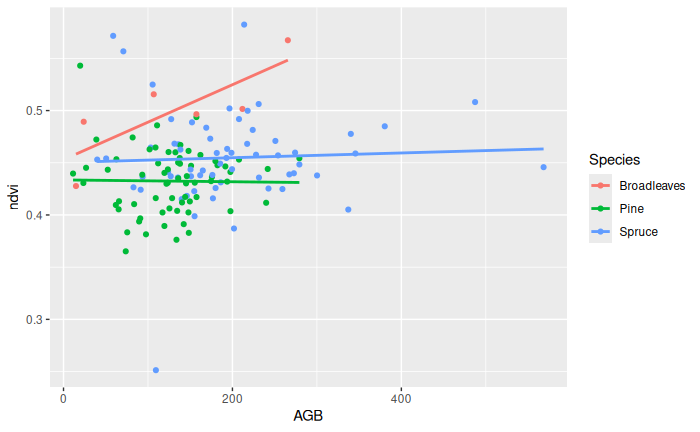

```r
ggplot(prfl,aes(x=AGB,y=ndvi,color=Species)) + geom_point() + geom_smooth(method="lm",se=FALSE)
```

## 6.Classification - dominant species map

We need to standardize resolutions to make predictions for individual pixels. This is solved by resampling the 20 m images to 10 m and then stack them into one raster.

```r
# Resample and merge 10 m and 20 m Sentinel
s2_20m_resampled <- resample(s2_20m,s2_10m) # Resample
s2 <- c(s2_10m,s2_20m_resampled) # Stack
s2
```

```
class       : SpatRaster
size        : 448, 431, 14  (nrow, ncol, nlyr)
resolution  : 10, 10  (x, y)
extent      : 605470, 609780, 6596120, 6600600  (xmin, xmax, ymin, ymax)
coord. ref. : WGS 84 / UTM zone 32N (EPSG:32632)
source(s)   : memory
names       : Blue_10m, Green_10m, Red_10m, NIR_10m, Costa~l_20m, Blue_20m, ...
min values  :     1054,      1042,     949,    1077,         881,     1072, ...
max values  :     7764,      7608,    7564,    8561,   6973.1875,  7572.75, ...
```

We need to extract the pixel values at sample plot locations, remove possible no-data points, and prepare the data for classification.

```r
# Extract RS information
e <- extract(s2,vect(prfl))
dat <- cbind(prfl,e[-1]) # -1 for removing ID
dat <- st_drop_geometry(dat) # removing geometry

# Remove nodata points
dim(dat)
```

```
[1] 136  20
```

```r
dat <- dat[is.na(dat$NIR)==FALSE,]
dim(dat)
```

```
[1] 136  20
```

```r
# Convert species to factor (categorical R variable for classification
dat$Species <- factor(dat$Species,levels=c("Spruce","Pine","Broadleaves")) # or if you do not care about the order of species, just: as.factor(data$Species)
```

Classifying dominant species using *randomForest*

```r
# Classifiy dominant species
library(randomForest)
head(dat)
```

|  | plotID | SiteIndex | Age | AGB | Species | ndvi | Blue_10m | Green_10m | Red_10m | NIR_10m | CostalAerosol_20m | Blue_20m | Green_20m | Red_20m | RE1_20m | RE2_20m | RE3_20m | SWIR1_20m | SWIR2_20m | RE4_20m |
| --- | --- | --- | --- | --- | --- | --- | --- | --- | --- | --- | --- | --- | --- | --- | --- | --- | --- | --- | --- | --- |
| 1 | P10 | 14 | 9 | 272.74768 | Spruce | 0.4399410 | 1143 | 1264 | 1140 | 2931 | 1120.625 | 1158.625 | 1294.938 | 1158.500 | 1528.188 | 2550.938 | 2801.312 | 1891.062 | 1445.812 | 2998.562 |
| 2 | P100 | 14 | 40 | 191.61090 | Pine | 0.4464789 | 1156 | 1331 | 1179 | 3081 | 1096.438 | 1163.062 | 1320.875 | 1174.375 | 1566.375 | 2620.188 | 2984.875 | 1856.438 | 1411.812 | 3203.188 |
| 3 | P101 | 11 | 55 | 91.35791 | Spruce | 0.4241658 | 1142 | 1278 | 1139 | 2817 | 1088.812 | 1148.375 | 1274.688 | 1142.125 | 1483.438 | 2502.812 | 2832.500 | 1727.438 | 1335.812 | 3063.500 |
| 4 | P102 | 11 | 55 | 149.58604 | Pine | 0.4129693 | 1191 | 1312 | 1204 | 2898 | 1171.812 | 1196.312 | 1326.688 | 1219.500 | 1569.562 | 2518.312 | 2803.562 | 2032.438 | 1534.125 | 2999.125 |
| 5 | P104 | 14 | 40 | 253.98047 | Spruce | 0.4570611 | 1162 | 1282 | 1138 | 3054 | 1108.688 | 1164.562 | 1285.688 | 1144.750 | 1485.000 | 2686.125 | 3054.625 | 1782.000 | 1351.688 | 3250.188 |
| 6 | P105 | 11 | 65 | 139.92369 | Spruce | 0.4151500 | 1218 | 1308 | 1189 | 2877 | 1137.375 | 1173.188 | 1290.438 | 1179.188 | 1486.562 | 2555.000 | 2816.500 | 1949.375 | 1467.500 | 3025.688 |

```r
dat1 <- dat[,-c(1:4,6)] # Sub-setting species and spectral bands i.e. removing other field measured variables
rf1 <- randomForest(Species~.,data=dat1) # The ~. indicates that I will create a classification model that use all the data in dat1
rf1
```

```
Call:
 randomForest(formula = Species ~ ., data = dat1)
               Type of random forest: classification
                     Number of trees: 500
No. of variables tried at each split: 3

        OOB estimate of  error rate: 32.35%
Confusion matrix:
            Spruce Pine Broadleaves class.error
Spruce          41   21           2   0.3593750
Pine            15   51           0   0.2272727
Broadleaves      5    1           0   1.0000000
```

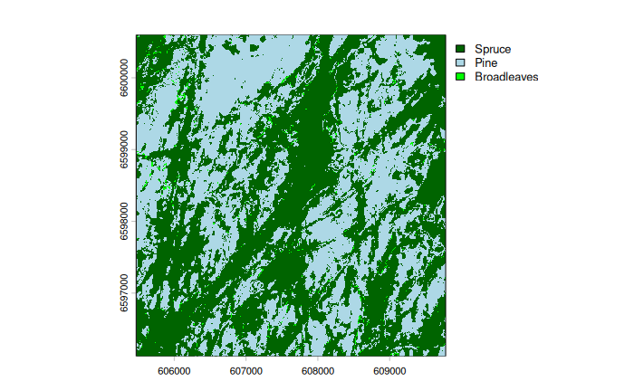

```r
sp <- predict(s2,rf1) # Predict on the raster file
plot(sp,col=c("darkgreen","lightblue","green")) # Make a plot
```

## 7. Regression - above ground biomass map (AGB)

We will use the measurements of biomass (AGB) on the sample plots to make a model to predict biomass. We will evaluate the prediction accuracy using the Root Mean Square Error. RMSE is calculated as the square root of the mean of the squared differences between observed values ($y_i$) and predicted values ($\hat{y_i}$) for a dataset of size *n*:
$$RMSE = \sqrt{\frac{1}{n} \sum_{i=1}^{n}(y_i - \hat{y}_i)^2}$$
Then we will make a scatter plot of the observed (y-axis) vs predicted values (fitted) (x-axis). For reasoning behind this see Piñeiro et al. (2008) [^1].

```r
# Predict AGB
rf1 <- randomForest(AGB~.,data=dat[,-c(1:3,5:6)]) # Doing the sub-setting of the data inside the data argument of the function
rf1
```

```
Call:
 randomForest(formula = AGB ~ ., data = dat[, -c(1:3, 5:6)])
               Type of random forest: regression
                     Number of trees: 500
No. of variables tried at each split: 4

          Mean of squared residuals: 6401.781
                    % Var explained: 8.79
```

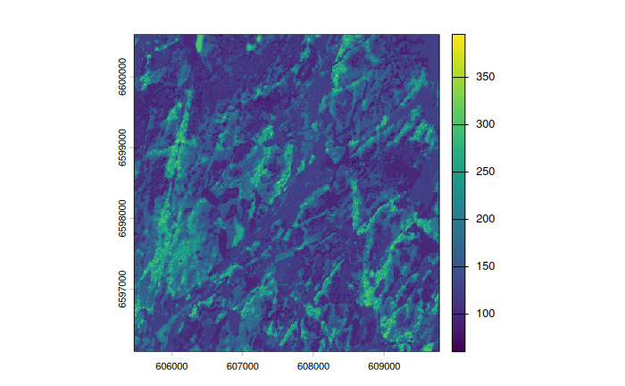

```r
agb <- predict(s2,rf1) # Predict on sentinel-2 image
plot(agb)
```

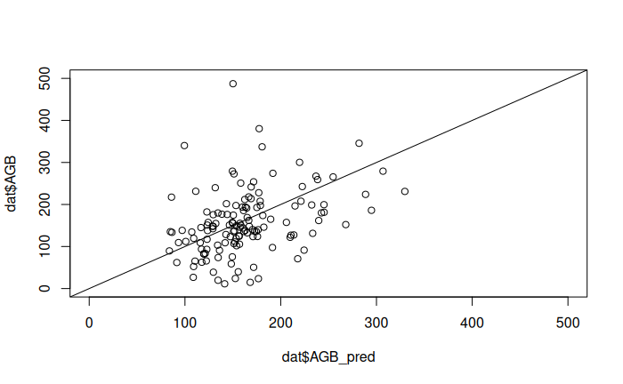

```r
# fitted value for sample plots
dat$AGB_pred <- predict(rf1)
plot(dat$AGB_pred,dat$AGB,ylim=c(0,500),xlim=c(0,500))
abline(0,1)
```

```r
# Compute root mean square error (RMSE)
rmse <- sqrt(mean((dat$AGB_pred-dat$AGB)^2))
# And compute it in percent relative to the mean biomass of my sample plots
rmse/mean(dat$AGB) * 100
```

```
[1] 50.22837
```

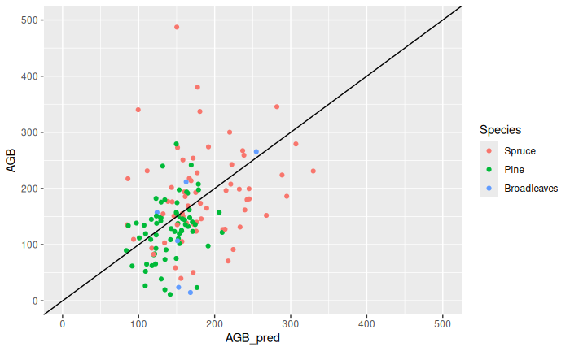

```r
# Plotting predicted vs observed.
ggplot(dat,aes(x=AGB_pred,y=AGB,color=Species)) + geom_point() + geom_abline() + coord_cartesian() + xlim(0,500)+ ylim(0,500)
```

# **Part 2: Creating a forest mask**

**Goal:** The prediction maps of dominant species and AGB cover areas outside the forest and areas lacking reference data. Therefore, we need to mask out these regions. We will explore two methods to achieve this.

We can obtain a forest mask in several ways: 1. We can collect data covering the entire area and use classification as for species above. 2. Perform a similar analysis as in lab exercise 1 (refer to lab 1). 3. Segment the image into similar units and select the units to be included (Outline below).

## De-mystifying segmentation

1. Generate a systematic sample.
2. Group samples based on spectral similarity using k-means clustering.
3. Predict (or more accurately, “impute”) group labels from k-means to the entire image using k-nearest neighbor.
4. Apply a spatial filter to remove “salt and pepper” noise.

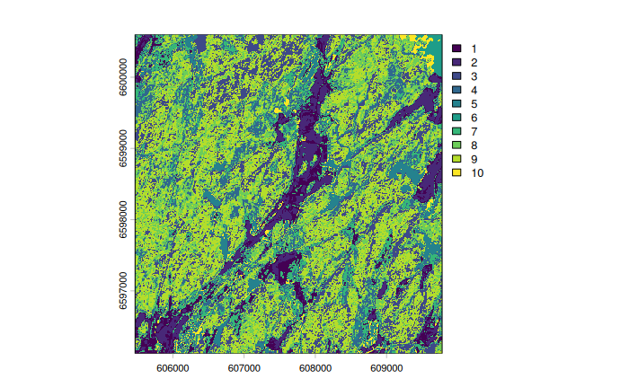

```r
library(dplyr) # Package needed for piping (%>% ) which improves code readability
library(class) #  General classification pacakge part of core R
set.seed(123) # I have added a seed to look the randomness that will occur in the analysis, i.e. the results will be the same next time I run the code.
g <- st_sample(aoi,size=1000,type="regular") # Systematic sample of points
g <- st_as_sf(g) #Convert
e3 <- extract(s2_10m,g)
obs <- na.omit(e3[,-1])

km <- kmeans(obs,centers=10) # k-means clustering. An unsupervised clustering algorithm. I selected 10 groups

#Function need to use knn in the predict.rast function
predfun <- function(model, data) {
  pred <- knn(obs,data,km$cluster,k=1) # I selected one neighbor
}

knnmap <- predict(s2_10m,obs,fun=predfun) #Impute values, note that the input is data not a model
plot(knnmap)
```

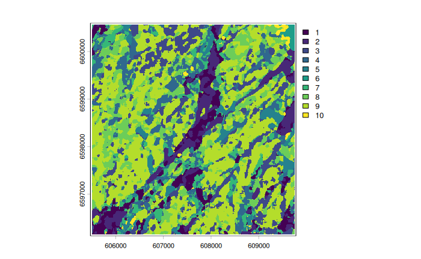

```r
knnmap2 <- focal(knnmap,w=7,fun="modal") # Run a focal majority filter to remove "salt and pepper"
plot(knnmap2)
```

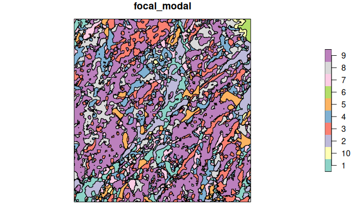

```r
# Convert to polygons
poly <- as.polygons(knnmap2)
poly <- st_as_sf(poly) # Step to make it in the sf class
write_sf(poly,"data/kmeans.gpkg","kmeans")
plot(poly)
```

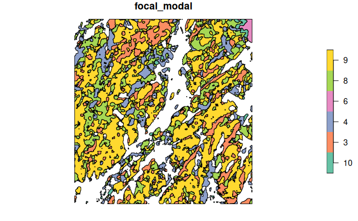

```r
# Checking cluster codes in GIS and
sel <- c(3,4,6,8,9,10) # My selection of means groups
poly2 <- poly %>% filter(focal_modal %in% sel) # Select the kmeans classes that I want from the vector data to plot (not really needed)
plot(poly2)
```

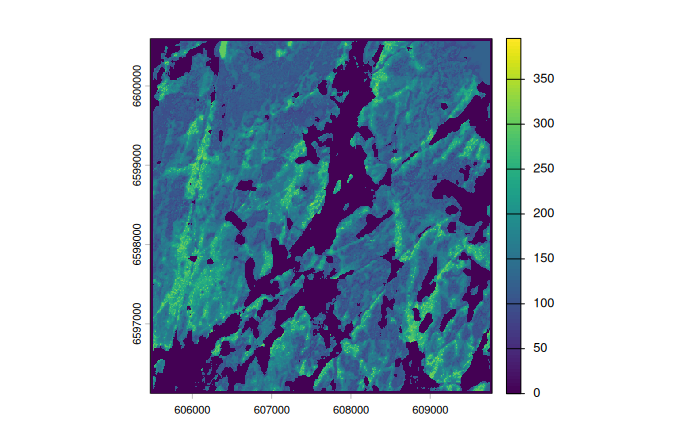

```r
mask <- knnmap2 %in% sel # Apply a filter to the raster data
agb_masked <- agb * mask # Remove the areas not forest and keep only forested areas.
plot(agb_masked)
```

```r
sp_masked <- sp * mask
sp_masked[sp_masked == 0] <- NA
par(mfcol=(c(1,2)))
plot(sp_masked,col=c("darkgreen","lightblue","green"),main="Classification")
plot(agb_masked,main="Regression" )
```

[figure not shown]

```r
knnmap2_masked <- knnmap2 * mask
knnmap2_masked[knnmap2_masked == 0] <- NA
par(mfcol=(c(1,2)))
```

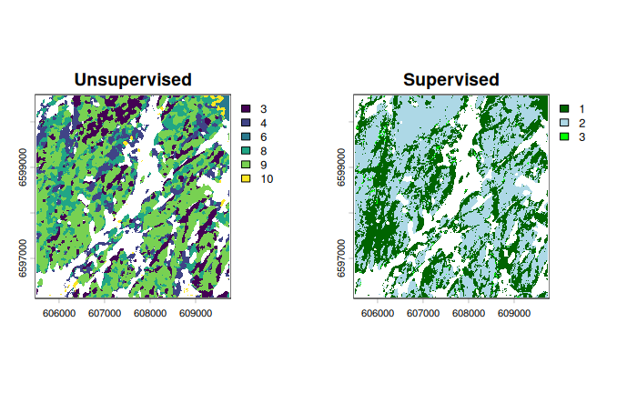

```r
plot(knnmap2_masked,main="Unsupervised" )
plot(sp_masked,col=c("darkgreen","lightblue","green"),main="Supervised")
```

# References

[^1]: Piñeiro, G., Perelman, S., Guerschman, J. P., & Paruelo, J. M. (2008). How to evaluate models: Observed vs. predicted or predicted vs. observed? Ecological Modelling, 216(3), 316–322. https://doi.org/10.1016/j.ecolmodel.2008.05.006